# Efficacy of a Novel Antihypertensive Drug in treating Stage 1 Hypertension

Author

Harchit Kaur

Published

April 28, 2026

Research question:

Does the new drug (AH-27) leads to a greater reduction in SBP?

## 1 Prepare Session

Load the required libraries, import, screen and correct the data.

## 2 Explore the data

It’s always a good idea to get to know your data, both by exploring them numerically and graphically. Variables in dataset:

- reduction_sbp (outcome) meassures the reduction of systolic blood pressure in mmHg
- basline_sbp meassure the baselne systloic blood pressure in mmHg
- treatment_group shows if the patient received new drug or standard therapy for 8 weeks

### 2.1 Nummerically

In Table 1 we see descriptive statistics for the variables of interest.

Table 1: Descriptive statistics for the variables of interest

|  | baseline_sbp | reduction_sbp |
| --- | --- | --- |
| nbr.val | 180.0 | 180.0 |
| nbr.null | 0.0 | 0.0 |
| nbr.na | 0.0 | 0.0 |
| min | 120.5 | -9.8 |
| max | 173.9 | 27.4 |
| range | 53.4 | 37.2 |
| sum | 27139.0 | 1942.3 |
| median | 151.3 | 10.0 |
| mean | 150.8 | 10.8 |
| SE.mean | 0.7 | 0.5 |
| CI.mean.0.95 | 1.4 | 1.0 |
| var | 93.2 | 47.8 |
| std.dev | 9.7 | 6.9 |
| coef.var | 0.1 | 0.6 |
| skewness | -0.2 | 0.0 |
| skew.2SE | -0.5 | 0.1 |
| kurtosis | 0.2 | -0.2 |
| kurt.2SE | 0.3 | -0.3 |
| normtest.W | 1.0 | 1.0 |
| normtest.p | 0.4 | 0.3 |

### 2.2 Graphically

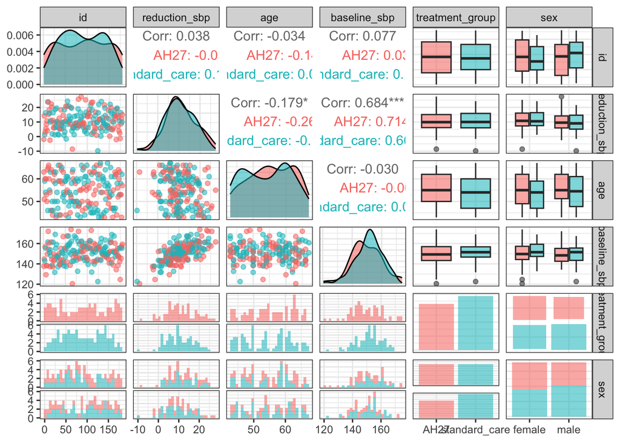

Figure 1: Overview of relationships within variables

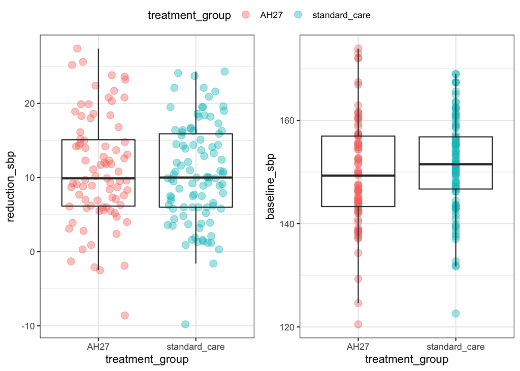

Figure 2: good graph

In Figure 2 we see that both new drug (AH27) and standard care are equally good in reduction of systolic blood pressure. But we see that baseline_sbp was slightly higher for standard care. If are hypothesises of higher baseline_sbp leads to higher reduction is true than we can not inteprete that both therapies are equally good. We will have to fit some models and compare them prior concluding something here !

## 3 Fit model

### 3.1 Formulate and compare

```r
#fit models

model.00 <- lm(reduction_sbp ~ 1, data = BP) # ~1 indicates with intercept
model.01 <- lm(reduction_sbp ~ baseline_sbp, data = BP)
model.02 <- lm(reduction_sbp ~ treatment_group, data = BP)
model.03 <- lm(reduction_sbp ~ age, data = BP)
model.04 <- lm(reduction_sbp ~ sex, data = BP)
model.05 <- lm(reduction_sbp ~ sex + treatment_group, data = BP)
model.06 <-  lm(reduction_sbp ~ age + sex, data = BP)
model.07 <- lm(reduction_sbp ~ treatment_group + age, data = BP)
model.08 <- lm(reduction_sbp ~ baseline_sbp * treatment_group, data = BP)
model.09  <- lm(reduction_sbp ~ sex * treatment_group, data = BP)
model.10 <-  lm(reduction_sbp ~ age * sex, data = BP)
model.11 <- lm(reduction_sbp ~ treatment_group * age, data = BP)
model.12 <- lm(reduction_sbp ~ treatment_group + age + sex + baseline_sbp, data = BP)

kable(compare_performance(model.00, model.01, model.02, model.03, model.04, model.05, model.06,model.07, model.08, model.09, model.10, model.11, model.12 ), digits= 3)

AIC <- AIC(model.12)
# 1088.547 lowest AIC of model.12
```

[output not shown]

I choose model.12 because it has the lowest AIC= 1088.55 , which tells us that its the best model to work with for interpretating results.

### 3.2 Validate the preferred model

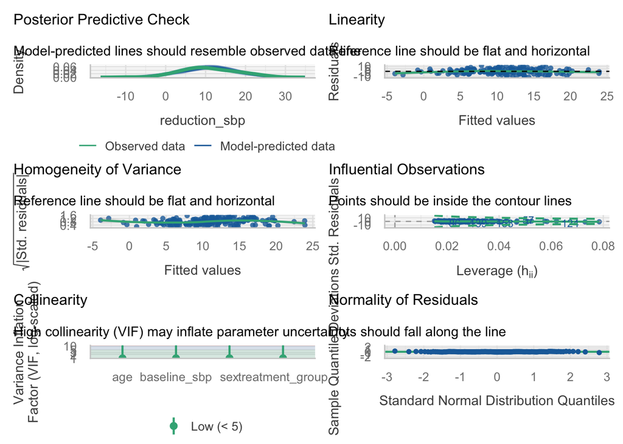

Figure 3: Model diagnostics: these look pretty good

```r
# First thing: check overdispersion for *lm functions* and glm!!!
  check_model(model.12)
```

In Figure 3 we see the model represents the reality very well. Homogneity of Variance doesn’t look so nice, it points out towards heteroscedasticity meaning that standard errors might be unreliable. The normality of residuals and collinearity look of the model fine though.

## 4 Interpret model

|  | Estimate | Std. Error | t value | Pr(>\|t\|) |
| --- | --- | --- | --- | --- |
| (Intercept) | -52.808 | 6.491 | -8.136 | 0.000 |
| treatment_groupstandard_care | -1.471 | 0.738 | -1.994 | 0.048 |
| age | -0.158 | 0.052 | -3.045 | 0.003 |
| sexmale | -1.144 | 0.734 | -1.559 | 0.121 |
| baseline_sbp | 0.488 | 0.038 | 12.810 | 0.000 |

This findings is corroborated by Figure 4, in which we see that, that older patients have reduced reponse to treatment irrespective of the drug type. We also see that the new drug is slightly better than the standardcare therapy.

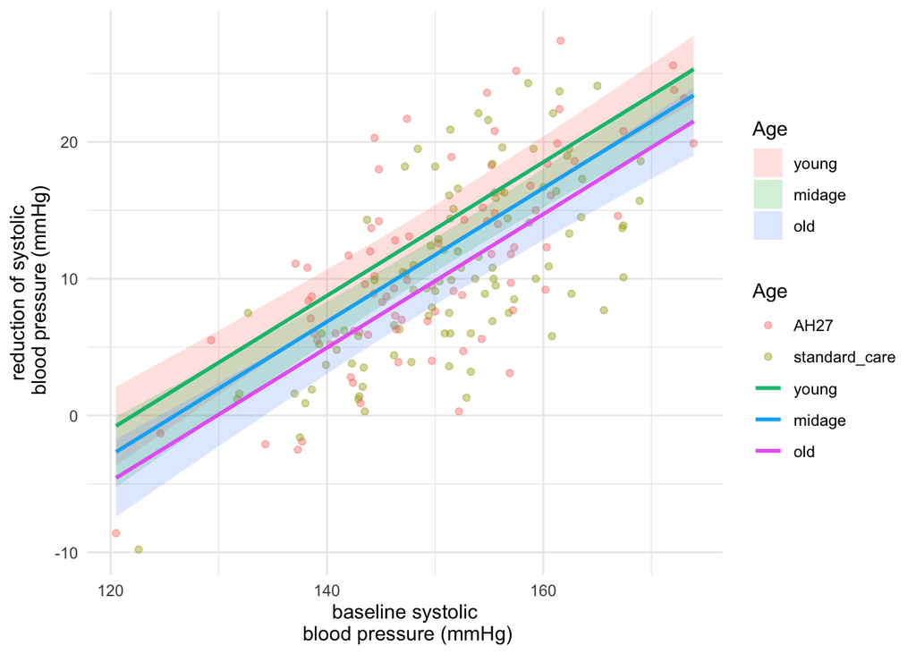